# Topic 6 - Regularizations and Resampling methods

MSDA - MSDA7003 Machine Learning

KT Wong

Faculty of Social Sciences, HKU

2024-11-15

The materials in this topic are drawn from (Lantz 2023) and (James et al. 2023)

## Roadmap

- Regularization
  - Lasso regression
  - Ridge regression
  - Elastic net regression (we will not cover it)
- Resampling methods
  - Bootstrapping
  - Cross-validation

## Regularization

- Regularization is a method used to **prevent overfitting** in a model
  - it **adds a penalty term** to the loss function that the model is trying to minimize
  - this penalty term discourages the model from learning complex patterns in the training data that do not generalize to new data
- Regularization is particularly useful when the number of predictors in a model is large
- Regularization is a form of **shrinkage** method
  - it works by shrinking the coefficients of the predictors towards zero
  - this has the effect of reducing the variance of the model, at the cost of introducing some bias
- Here, we discuss two popular regularization methods
  - Lasso regression
  - Ridge regression

$\newcommand{\E}{\mathbb{E}} \newcommand{\E}{\mathbb{E}} \newcommand{\var}{\mathrm{var}} \newcommand{\cov}{\mathrm{cov}} \newcommand{\Var}{\mathrm{var}} \newcommand{\Cov}{\mathrm{cov}} \newcommand{\Corr}{\mathrm{corr}} \newcommand{\corr}{\mathrm{corr}} \newcommand{\L}{\mathrm{L}} \renewcommand{\P}{\mathrm{P}} \newcommand{\independent}{{\perp\!\!\!\perp}} \newcommand{\indicator}[1]{ \mathbf{1}\{#1\} }$

## Ridge Regression

- Ridge regression adds a penalty term to the least squares loss function
  - the penalty term is the sum of the squares of the coefficients multiplied by a constant $\lambda$
  - $\lambda$ is a **tuning parameter** that controls the strength of the penalty
  - the larger the value of $\lambda$, the greater the penalty on the coefficients

$$\text{Ridge loss} = \sum_{i=1}^{n} (y_i - \hat{y}_i)^2 + \lambda \sum_{j=1}^{p} \beta_j^2$$

$\quad$ where $\lambda \geq 0$ is a hyperparameter controlling how much to shrink coefficients

- it turns out that the choice of $\lambda$ is crucial
  - if $\lambda$ is too small, the model will overfit
  - if $\lambda$ is too large, the model will underfit

## Ridge Regression - An illustration

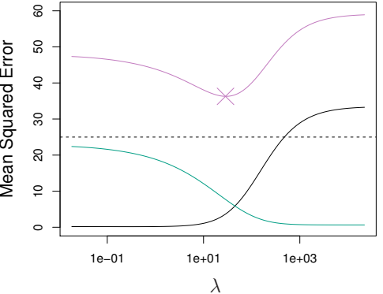

## Lasso (Least Absolute Shrinkage and Selection Operator)

- Lasso regression adds a penalty term to the least squares loss function
  - the penalty term is the sum of the absolute values of the coefficients multiplied by a constant $\lambda$
  - $\lambda$ is a tuning parameter that controls the strength of the penalty
  - the larger the value of $\lambda$, the greater the penalty on the coefficients

$$\text{Lasso loss} = \sum_{i=1}^{n} (y_i - \hat{y}_i)^2 + \lambda \sum_{j=1}^{p} |\beta_j|$$

- the (ℓ1) penalty in LASSO has the effect of forcing some of the coefficient estimates to be exactly equal to zero when the tuning parameter λ is sufficiently large
  - the LASSO performs variable selection
  - the LASSO yields `sparse` models — models that involve only a subset of the variables

## Lasso Regression - An illustration

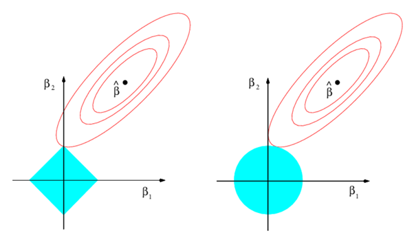

## LASSO - Advantages and Disadvantages

- LASSO has the advantage of producing simpler and more interpretable models
  - it can be useful when we have a large number of predictors and we believe that only a subset of them are important
  - it can be used for variable selection
- LASSO has the disadvantage of being computationally intensive
- LASSO won’t work well when true models are not sparse
  - many of the variables are important
- With high collinearity, LASSO arbitrarily selects one feature among the correlated features
- Coefficient estimates vary quite a bit with slightly different samples
  - predictions will be similar
- LASSO can select at most n variables

## Resampling methods

- Resampling is a method that involves **repeatedly drawing samples from a training set and refitting a model of interest to each sample** in order to obtain additional information about the fitted model
- The two most common resampling methods are
  - bootstrapping
  - cross-validation
- Main idea
  - These methods refit a model of interest to samples formed from the **training set** to obtain additional information about the fitted model
- The bootstrap method involves repeatedly sampling observations from the training set with replacement
  - refitting the model to each “new” sample
- Cross-validation is used to “estimate” the **test error** associated with a given model in order to evaluate its performance

## Bootstrapping

- Fundamental idea: pretend the observed data is the population
- The general procedures for bootstrapping is as follows
  - Draw a sample of size $n$ with `replacement` from the observed data
  - Fit a model to the bootstrap sample
  - Repeat the above two steps $B$ times to produce $B$ bootstrap datasets
    - $B$ is a large number (e.g. 1000)
  - Calculate the quantity of interest for each of the $B$ models (say $\alpha$, here)
    - they are the bootstrap estimates of $\alpha$

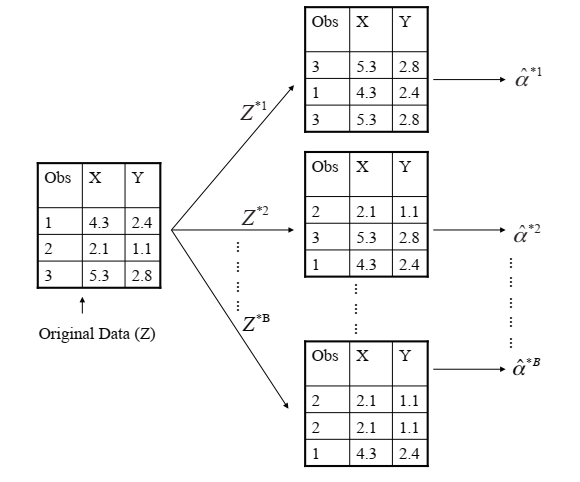

## A major use of bootstrapping in Tree-based Models

- **Bagging** (bootstrap aggregating) and **Random Forests** are two popular ensemble learning methods that use bootstrapping
- **Bagging** is a method that involves creating multiple copies of the original training data set using the bootstrap method
  - build a separate (classification/regression) tree model on each bootstrap sample
  - combine the results of the models to make a prediction
- **Random Forests**
  - a random forest is a slight variation of bagging that builds a large collection of **de-correlated trees**
    - each tree is built using a different bootstrap sample of the data
    - at each split in the tree, randomly selecting a subset of the predictors at each split
      - this helps to decorrelate the trees
    - the final prediction is made by combining the predictions of the individual trees

## R illustration of Random Forest

- Fit a bagging model and a random forest model to the Boston housing data
  - the response variable is `medv` (median house value)
  - the predictors are all other variables in the data set
- We will use the `randomForest` package to fit the models
- load the data and split it into training and test sets

```r
library(tidyverse)
library(randomForest)

# load boston data

boston<- read_csv("https://raw.githubusercontent.com/kwan-MSDA/MSDA7003/refs/heads/main/Boston.csv")

boston<- boston %>% select(-c("...1"))
# Split the data into training and test sets

set.seed(123)

train<- boston %>% sample_frac(0.75)
test<- anti_join(boston, train)
```

## Fit a bagging model and a random forest model

- fit a bagging model

```r
# Fit bagging model

set.seed(123)

bagging <- randomForest(medv~., train, mtry = 12, ntree = 500)

bagging
```

```
Call:
 randomForest(formula = medv ~ ., data = train, mtry = 12, ntree = 500)
               Type of random forest: regression
                     Number of trees: 500
No. of variables tried at each split: 12

          Mean of squared residuals: 10.58906
                    % Var explained: 87.57
```

- fit a random forest model
  - for regression problems, the default value of $mtry=\frac{p}{3}$; for classification problem $mtry=\sqrt{p}$

```r
# Fit random forest

set.seed(123)

rf <- randomForest(medv~., train, mtry = 4, ntree = 500)

rf
```

```
Call:
 randomForest(formula = medv ~ ., data = train, mtry = 4, ntree = 500)
               Type of random forest: regression
                     Number of trees: 500
No. of variables tried at each split: 4

          Mean of squared residuals: 10.82981
                    % Var explained: 87.29
```

## Plot MSE against the number of trees

Plot the model with MSE against the number of trees

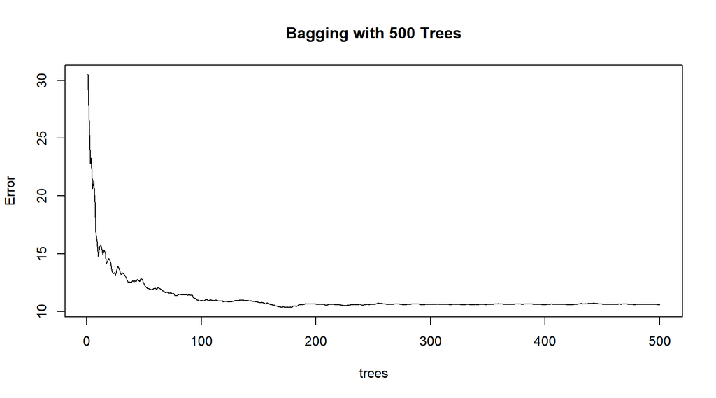

```r
plot(bagging, main = "Bagging with 500 Trees")
```

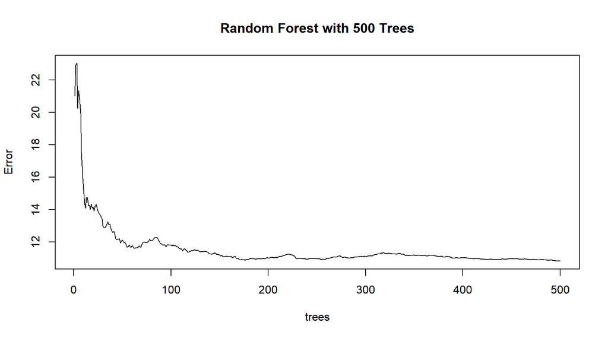

```r
plot(rf, main = "Random Forest with 500 Trees")
```

```r
# Plot the importance of the predictors

library(vip)

importance(rf, num_features = 10)
```

```
        IncNodePurity
crim        1914.9469
zn           194.6403
indus       1500.1814
chas         164.6948
nox         1882.6321
rm          9862.0014
age          937.4956
dis         2040.2877
rad          235.6012
tax          883.0365
ptratio     2322.9746
lstat      10088.8676
```

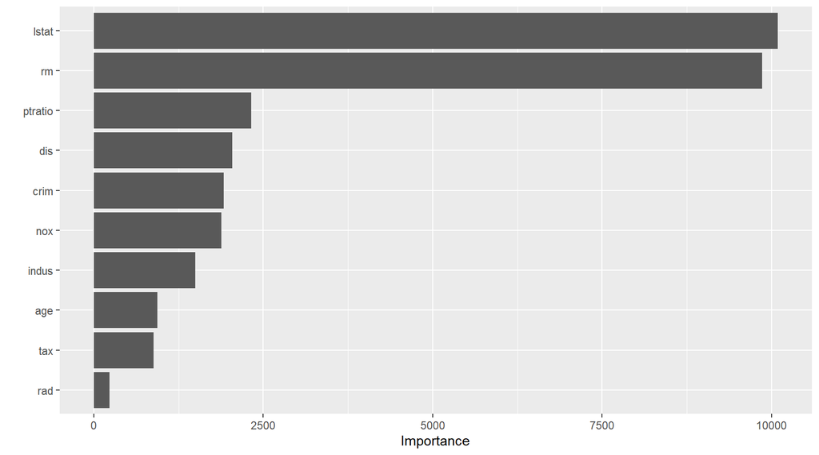

```r
vip::vip(rf, num_features = 10)
```

## Test error of the models

- Make predictions on the test set

```r
predictions_bagging <- predict(bagging, test)
predictions_rf <- predict(rf, test)

cat("the mean square test error for Bagging" , (mean((predictions_bagging - test$medv)^2)), "\n")
```

```
the mean square test error for Bagging 14.13697
```

```r
cat("the mean square test error for Random Forest" , (mean((predictions_rf - test$medv)^2)), "\n")
```

```
the mean square test error for Random Forest 12.13714
```

- as a comparison, we can also fit a linear regression model

```r
# Fit a linear regression model

lm_fit<- lm(medv~., data = train)
pred_lm<- predict(lm_fit, test)

cat("the mean square test error for linear Regression Tree" , (mean((pred_lm - test$medv)^2)), "\n")
```

```
the mean square test error for linear Regression Tree 25.4131
```

- as a comparison, we can also fit a single regression tree model

```r
# Fit a single regression tree model

library(rpart)

set.seed(123)

tree_fit<- rpart(medv~., data = train)

pred_tree<- predict(tree_fit, test)

cat("the mean square test error for Single Regression Tree" , (mean((pred_tree - test$medv)^2)), "\n")
```

```
the mean square test error for Single Regression Tree 26.56864
```

## Cross-Validation - Validation Set Approach first

- we have hyperparameters to “tune”

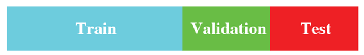

- Training set: A subsample used to fit a model (e.g. estimate model parameters)
- Validation set: A subsample used for model selection (e.g. hyperparameter tuning)
- Test set: A subsample used `only` for (final) model assessment
- Validation-set approach: randomly divide the training set into two parts
  - a training set and a validation set (holdout set)
  - fit the model on the **training set** and then assess its performance on the **validation set**
  - the resulting validation-set error provides an estimate of the test error
    - we can use this estimate to select the best model (e.g. the best hyperparameters)

## Cross-Validation — K-fold Cross-Validation

- K-fold cross-validation is a generalization of the validation set approach
  - the training set is split into $K$ smaller sets
  - a model is trained using $K-1$ of the folds as training data
  - the resulting model is validated on the remaining part of the data
  - the process is repeated $K$ times, with each of the $K$ folds used exactly once as the validation data
  - the $K$ results from the folds can then be combined to produce a single estimation of the test error

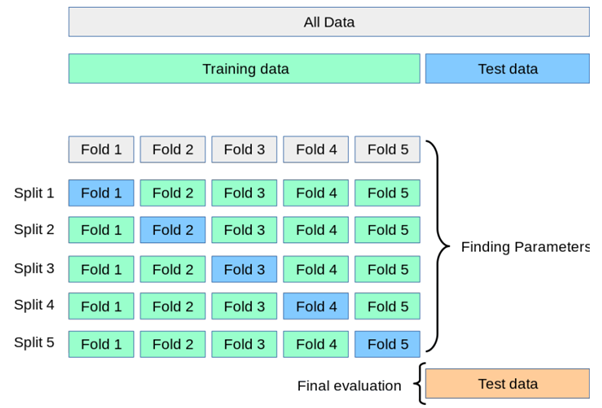

## Cross-Validation - More details

- The choice of $K$ in K-fold cross-validation is somewhat arbitrary
  - the most common choice is $K = 10$
  - but $K = 5$ or $K = 20$ are also popular choices
  - when setting $K=n$, the method is referred to as `leave-one-out cross-validation` (LOOCV)
- The computational cost can become a concern when $K$ is large
  - particularly when there are **many tuning parameters**
  - particularly when the model fitting procedure is computationally expensive
- Some formal notations (for a quantitative response)
  - Let the $K$ parts be $C_1, C_2, . . . C_K$, where $C_k$ denotes the indices of the observations in part $k$
  - There are $n_k$ observations in part $k$
    - if $N$ is a multiple of $K$, then $n_k = n/K$
  - Compute $CV_{(K)} = \sum^K_{k=1} \frac{n_k}{n} MSE_k$ where $MSE_k = \sum_{i∈C_k}(y_i − \hat{y}_i)^2/n_k$, and $\hat{y}_i$ is the fit for observation $i$, obtained from the data with part $k$ removed

## Lab 6 - Regularization and Cross-validation

- In this lab, we will use the `glmnet` package to perform Lasso and Ridge regression
  - we will use the `cv.glmnet()` function to perform cross-validation for Lasso and Ridge regression
- We will use the Boston housing data set to predict the median house value in Boston suburbs

```r
library(tidyverse)

boston<- read_csv("https://raw.githubusercontent.com/kwan-MSDA/MSDA7003/refs/heads/main/Boston.csv")
boston <- boston %>% select(-c(1))
```

```r
set.seed(123)

# Split the data into training and test sets

train<- boston %>% sample_frac(0.75)
test<- anti_join(boston, train)

# Fit a linear regression model

lm.fit<- lm(medv~., data = train)

# Compute the test MSE

lm.pred<- predict(lm.fit, test)

lm_test_MSE<- mean((lm.pred - test$medv)^2)
```

## Lasso

- main reference: [An Introduction to glmnet](https://glmnet.stanford.edu/articles/glmnet.html)

```r
# Fit a Lasso model
library(glmnet)

x<- model.matrix(medv~., data = train)[,-1]
y<- train$medv

lasso.fit<- glmnet(x, y, alpha = 1)

#print(lasso.fit)

coef(lasso.fit, s=0.5)
```

```
13 x 1 sparse Matrix of class "dgCMatrix"
                     s1
(Intercept) 19.66860495
crim        -0.01362019
zn           .
indus        .
chas         2.70736897
nox          .
rm           3.76370528
age          .
dis         -0.15016061
rad          .
tax          .
ptratio     -0.70343490
lstat       -0.58808520
```

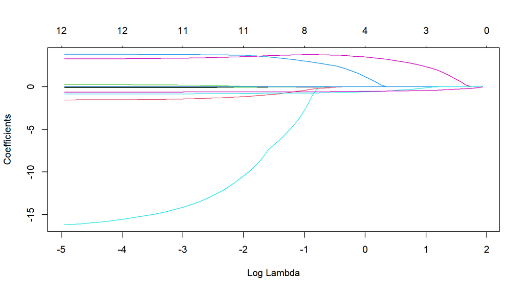

```r
# Plot the coefficients

plot(lasso.fit, xvar = "lambda")
```

## Lasso - Cross-validation

```r
# Perform cross-validation to select the optimal value of lambda

cv.fit_lasso<- cv.glmnet(x, y, alpha = 1, type.measure = "mse", nfolds = 10)

print(cv.fit_lasso)
```

```
Call:  cv.glmnet(x = x, y = y, type.measure = "mse", nfolds = 10, alpha = 1)

Measure: Mean-Squared Error

    Lambda Index Measure    SE Nonzero
min 0.0164    66   23.31 3.427      12
1se 0.3866    32   26.63 3.785       8
```

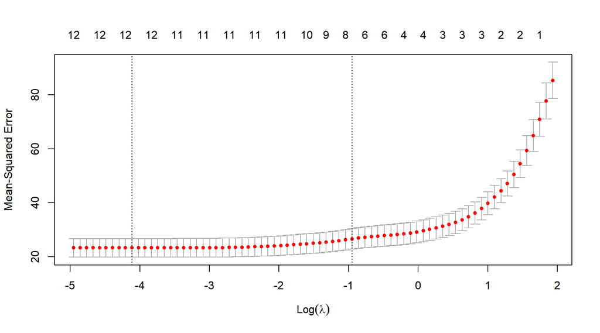

```r
# Plot the cross-validation error as a function of lambda

plot(cv.fit_lasso)
```

```r
# minimum lambda

cat("the min lambda for lasso regression = ", cv.fit_lasso$lambda.min, "\n")
```

```
the min lambda for lasso regression =  0.01635224
```

```r
cat("the 1se lambda for lasso regression = ", cv.fit_lasso$lambda.1se, "\n")
```

```
the 1se lambda for lasso regression =  0.386647
```

```r
# Compute the test MSE

# reference: https://www.rdocumentation.org/packages/glmnet/versions/4.1-8/topics/cv.glmnet

lasso_cv.pred_min<- predict(cv.fit_lasso, s = cv.fit_lasso$lambda.min, newx = model.matrix(medv~., data = test)[,-1])

lasso_cv.pred_1se<- predict(cv.fit_lasso, s = cv.fit_lasso$lambda.1se, newx = model.matrix(medv~., data = test)[,-1])

cat("the mean square test error for min lambda LASSO" , mean((lasso_cv.pred_min - test$medv)^2), "\n")
```

```
the mean square test error for min lambda LASSO 25.43376
```

```r
cat("the mean square test error for 1se lambda LASSO" , mean((lasso_cv.pred_1se - test$medv)^2), "\n")
```

```
the mean square test error for 1se lambda LASSO 27.43652
```

## Ridge regression

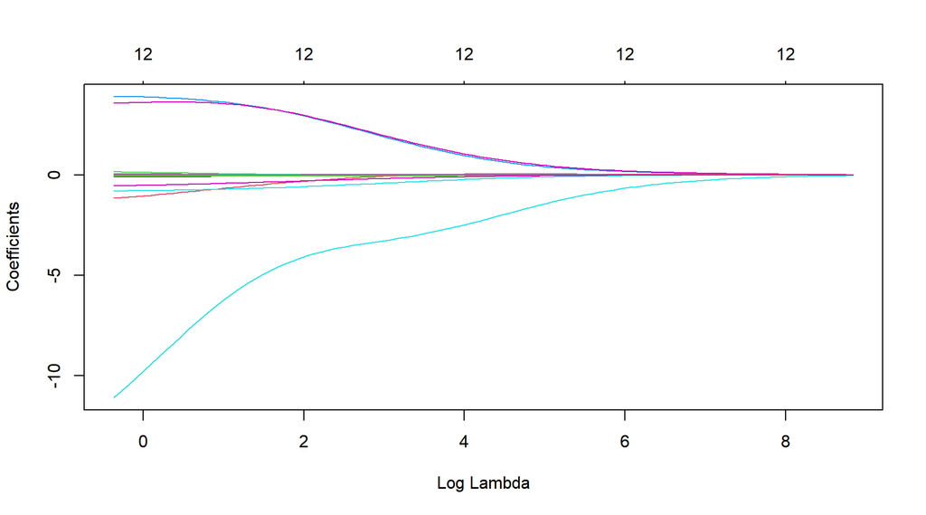

```r
# Fit a ridge regression model

ridge.fit<- glmnet(x, y, alpha = 0)

plot(ridge.fit, xvar = "lambda")
```

## Ridge regression - Cross-validation

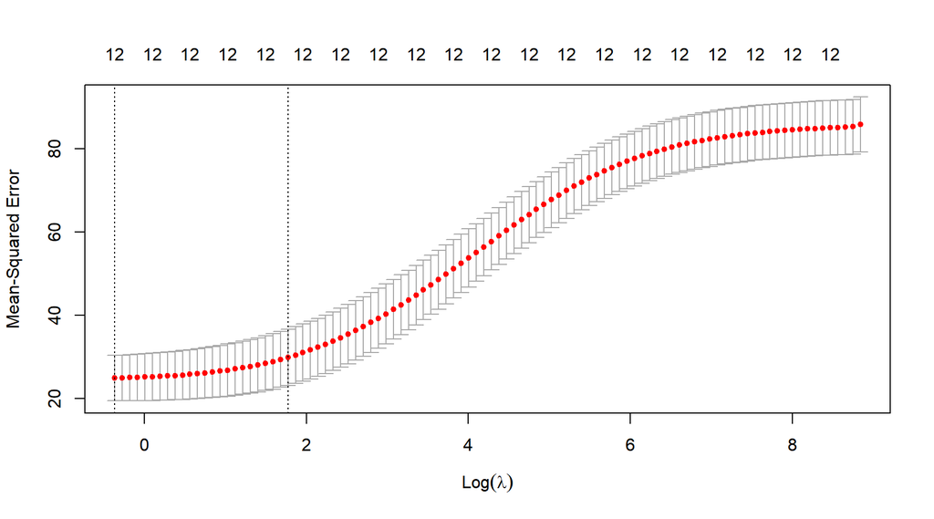

```r
# Perform cross-validation to select the optimal value of lambda

cv.fit_ridge<- cv.glmnet(x, y, type.measure = "mse", nfolds = 10, alpha = 0)

plot(cv.fit_ridge)
```

```r
# minimum lambda

cat("the min lambda for ridge regression = ", cv.fit_ridge$lambda.min, "\n")
```

```
the min lambda for ridge regression =  0.691576
```

```r
cat("the 1se lambda for ridge regression = ", cv.fit_ridge$lambda.1se, "\n")
```

```
the 1se lambda for ridge regression =  5.876691
```

```r
# Compute the test MSE

ridge_cv.pred_min<- predict(cv.fit_ridge, s = cv.fit_ridge$lambda.min, newx = model.matrix(medv~., data = test)[,-1])

ridge_cv.pred_1se<- predict(cv.fit_ridge, s = cv.fit_ridge$lambda.1se, newx = model.matrix(medv~., data = test)[,-1])

cat("the mean square test error for min lambda" , mean((ridge_cv.pred_min - test$medv)^2), "\n")
```

```
the mean square test error for min lambda 25.24048
```

```r
cat("the mean square test error for 1se lambda" , mean((ridge_cv.pred_1se - test$medv)^2), "\n")
```

```
the mean square test error for 1se lambda 28.50104
```

## Summary for Linear Model, LASSO and Ridge regression

- Compare the test MSE of the linear regression, Lasso, and Ridge regression models

```r
# Compare the test MSE of the linear regression, Lasso, and Ridge regression models

lm.pred<- predict(lm.fit, test)

cat("Linear regression test MSE: ", mean((lm.pred - test$medv)^2), "\n")
```

```
Linear regression test MSE:  25.4131
```

```r
cat("Lasso test MSE using min lambda: ", mean((lasso_cv.pred_min - test$medv)^2), "\n")
```

```
Lasso test MSE using min lambda:  25.43376
```

```r
cat("Lasso test MSE using 1se lambda: ", mean((lasso_cv.pred_1se - test$medv)^2), "\n")
```

```
Lasso test MSE using 1se lambda:  27.43652
```

```r
cat("Ridge regression test MSE using min lambda: ", mean((ridge_cv.pred_min - test$medv)^2), "\n")
```

```
Ridge regression test MSE using min lambda:  25.24048
```

```r
cat("Ridge regression test MSE using 1se lambda: ", mean((ridge_cv.pred_1se - test$medv)^2), "\n")
```

```
Ridge regression test MSE using 1se lambda:  28.50104
```

## Summary of the coefficients

- compare the coefficients of the three models

|  | Linear.regression | Lasso.1se.rule | Lasso.min.lambda | Ridge.regression.1se.rule | Ridge.regression.min.lambda |
| --- | --- | --- | --- | --- | --- |
| (Intercept) | 42.1587 | 22.2030 | 40.9240 | 24.6525 | 33.6267 |
| crim | -0.1112 | -0.0232 | -0.1055 | -0.0664 | -0.0926 |
| zn | 0.0544 | 0.0002 | 0.0513 | 0.0191 | 0.0376 |
| indus | -0.0152 | 0.0000 | -0.0205 | -0.0736 | -0.0613 |
| chas | 3.7988 | 2.9892 | 3.7991 | 3.1323 | 3.8999 |
| nox | -16.6374 | -2.1093 | -15.6653 | -4.4208 | -11.0923 |
| rm | 3.2451 | 3.7872 | 3.2932 | 3.1456 | 3.5550 |
| age | 0.0041 | 0.0000 | 0.0013 | -0.0083 | -0.0016 |
| dis | -1.5617 | -0.3335 | -1.5215 | -0.3864 | -1.1672 |
| rad | 0.2784 | 0.0000 | 0.2491 | 0.0128 | 0.1450 |
| tax | -0.0105 | 0.0000 | -0.0092 | -0.0028 | -0.0050 |
| ptratio | -0.8688 | -0.7390 | -0.8566 | -0.6266 | -0.8074 |
| lstat | -0.6224 | -0.5997 | -0.6190 | -0.3352 | -0.5493 |

## CV for Cost Complexity Pruning

- In the context of decision trees, cross-validation can be used to select the optimal value of the `cost complexity parameter` $\alpha$
  - this parameter controls the trade-off between the complexity of the tree and its fit to the training data
- cost-complexity function: $R_\alpha(T) = R(T) + \alpha|T|$
  - where $R(T)$ is the error of the tree $T$
  - $|T|$ is the number of terminal nodes of the tree
  - $\alpha$ is a non-negative tuning parameter
- use cross-validation to select the optimal value of $\alpha$

## Cost Complexity Pruning using Cross-Validation

- the `printcp()` function can be used to display the cross-validated error for different values of $\alpha$
  - The `plotcp()` function can be used to plot the cross-validated error as a function of $\alpha$

```r
library(rpart)

# Fit a decision tree
boston.tree<- rpart(medv~., data = train)


# Display the cross-validated error for different values of alpha
printcp(boston.tree)
```

```
Regression tree:
rpart(formula = medv ~ ., data = train)

Variables actually used in tree construction:
[1] crim  dis   lstat rm

Root node error: 32384/380 = 85.222

n= 380

        CP nsplit rel error  xerror     xstd
1 0.452028      0   1.00000 1.00610 0.096337
2 0.194157      1   0.54797 0.70171 0.076785
3 0.072984      2   0.35382 0.43744 0.063182
4 0.031265      3   0.28083 0.32186 0.050971
5 0.029824      4   0.24957 0.32025 0.052259
6 0.024937      5   0.21974 0.32235 0.052269
7 0.011832      6   0.19481 0.30250 0.052172
8 0.010000      7   0.18297 0.28703 0.051128
```

- take a look at the plot of the cross-validated error as a function of $\alpha$

```r
# Plot the cross-validated error as a function of alpha
plotcp(boston.tree)
```

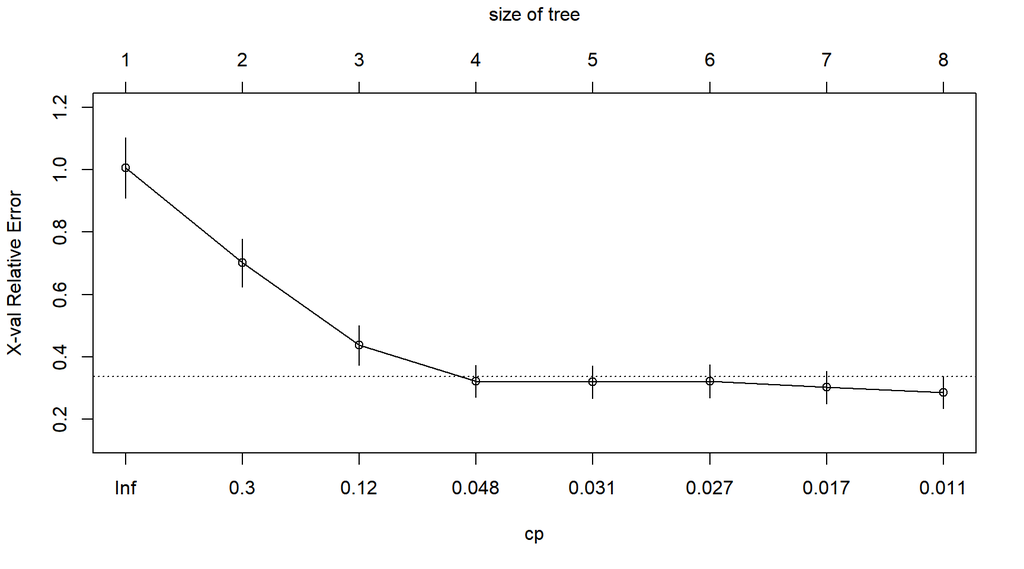

- test error for the pruned tree

```r
# test the pruned tree with the optimal value of alpha from cross-validation

cp_min<- boston.tree$cptable[which.min(boston.tree$cptable[,"xerror"]),"CP"]
cv_1se<- boston.tree$cptable[which.min(boston.tree$cptable[,"xerror"]),"xerror"]+ boston.tree$cptable[which.min(boston.tree$cptable[,"xerror"]),"xstd"]

cp_1se<- boston.tree$cptable[which.max(boston.tree$cptable[,"xerror"] <= cv_1se), "CP"]
prune.boston_1se<- prune(boston.tree,
                          cp=cp_1se)


prune.boston_min<- prune(boston.tree,
                          cp=cp_min)
# Compute the test MSE
boston.pred_min<- predict(prune.boston_min, test)
boston.pred_1se<- predict(prune.boston_1se, test)

cat("the mean square test error for min alpha" , mean((boston.pred_min - test$medv)^2), "\n")
```

```
the mean square test error for min alpha 26.56864
```

```r
cat("the mean square test error for 1se alpha" , mean((boston.pred_1se - test$medv)^2), "\n")
```

```
the mean square test error for 1se alpha 32.84495
```

## Appendix on Boosting

- Boosting is a general approach to statistical learning that can be applied to many statistical learning methods
  - let us focus on boosting for regression and classification trees
- As a recap, bagging and random forests involve
  - creating **multiple bootstrap samples** of the original training data set
  - fitting a separate decision tree to each each of them
  - combining all of the trees in order to create a single predictive model
- Boosting works in a similar way, except that the trees are grown **sequentially**
  - each tree is grown using information from **previously grown trees**
    - boosting **does not** involve bootstrap sampling
    - each tree is fit on a **modified version** of the original data set

## Appendix on Boosting

### its main idea

- let $f(x)$ be the true function we are trying to estimate, and $\hat{f}(x)$ be the current estimate of $f(x)$
- $y_i$ be the true response, and $r_i = y_i - \hat{f}(x_i)$ be the residual
- The following is the boosting algorithm for regression trees:
1. Set $\hat{f}(x) = 0$ and $r_i = y_i$ for all $i$ in the training set
2. For $b = 1, 2, . . . , B$, repeat the following
   - Fit a tree $\hat{f}_b$ with $d$ splits (i.e. $d + 1$ terminal nodes) to the training data $(X, r)$
   - Update $\hat{f}$ by adding in a shrunken version of the new tree:
     - $\hat{f}(x_i) ← \hat{f}(x_i) + λ\hat{f}b(x_i)$
   - Update the residuals, $r_i ← r_i − λ \hat{f}_b(x_i)$
3. Output the boosted model, $\hat{f}(x_i) = \sum_{b=1}^B λ\hat{f}_b(x_i)$

## Appendix on Boosting

- The figure below illustrates the boosting algorithm for regression trees

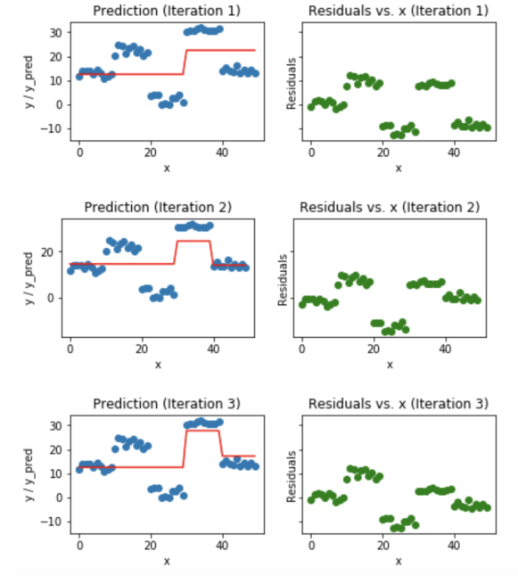

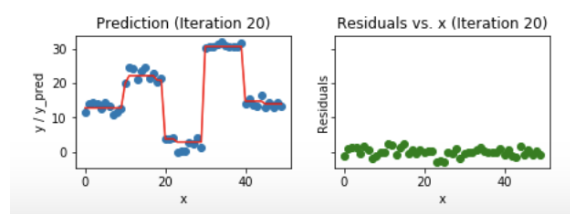

## Appendix on Boosting

- The most popular boosting algorithm now is `Gradient Boosting`
  - the algorithm is based on the principle of gradient descent
  - it fits a sequence of trees, where each tree is fit to the residuals of the previous tree
  - the predictions of the trees are combined to make a final prediction
- The `xgboost` package (“extreme gradient boosting”) is a popular implementation of the gradient boosting algorithm
  - known for its speed and performance
  - widely used in machine learning competitions

```r
library(xgboost)
library(caret)

x_train= data.matrix(train[,-13])
y_train= train$medv

x_test= data.matrix(test[,-13])
y_test= test$medv


xgb_train<- xgb.DMatrix(data = x_train, label = y_train)
xgb_test<- xgb.DMatrix(data = x_test, label = y_test)
```

```r
watchlist<- list(train=xgb_train, test=xgb_test)

model<- xgb.train(data = xgb_train, max_depth = 2, eta = 0.1,
                  nrounds = 100,
                  watchlist = watchlist,
                  objective = "reg:squarederror",
                  eval_metric = "rmse")
```

## Appendix on Boosting

- based on the previous model fit, we can find the optimal number of trees

```r
a<- which.min(model$evaluation_log$test_rmse)

final<- xgboost(data = xgb_train, max_depth = 2, eta = 1,
                  verbose = 0,
                  nrounds = a,
                  objective = "reg:squarederror")


final
```

```
##### xgb.Booster
raw: 90.9 Kb
call:
  xgb.train(params = params, data = dtrain, nrounds = nrounds,
    watchlist = watchlist, verbose = verbose, print_every_n = print_every_n,
    early_stopping_rounds = early_stopping_rounds, maximize = maximize,
    save_period = save_period, save_name = save_name, xgb_model = xgb_model,
    callbacks = callbacks, max_depth = 2, eta = 1, objective = "reg:squarederror")
params (as set within xgb.train):
  max_depth = "2", eta = "1", objective = "reg:squarederror", validate_parameters = "TRUE"
xgb.attributes:
  niter
callbacks:
  cb.evaluation.log()
# of features: 12
niter: 100
nfeatures : 12
evaluation_log:
  iter train_rmse
 <num>      <num>
     1  4.9252992
     2  4.2569717
   ---        ---
    99  0.5995196
   100  0.5949430
```

```r
mean((predict(final, x_test)- y_test)^2)
```

```
[1] 19.5874
```

## Appendix on Boosting

- we can perform cross-validation to select the optimal number of trees

```r
set.seed(123)
params<- list(eta = 0.01, max_depth = 3, objective = "reg:squarederror")
cv.nround<- 500
cv.nfold<- 10

boston_xgboost_cv<- xgb.cv(data = xgb_train, params = params, nfold = cv.nfold, nrounds = cv.nround,
                           early_stopping_rounds = 100, verbose = 0, maximize = FALSE,
                           prediction = TRUE, showsd = TRUE, metrics = "rmse")

boston_xgboost_final<- xgboost(data = xgb_train, params = params,
                               verbose = 0,
                               nrounds = boston_xgboost_cv$best_iteration)

mean((predict(boston_xgboost_final, x_test)- y_test)^2)
```

```
[1] 13.80249
```

## Appendix on Boosting

- we can also plot the importance of the predictors

```r
importance<- xgb.importance(feature_names = colnames(x_train), model = final)

xgb.plot.importance(importance, rel_to_first = TRUE, xlab = "Relative Importance")
```

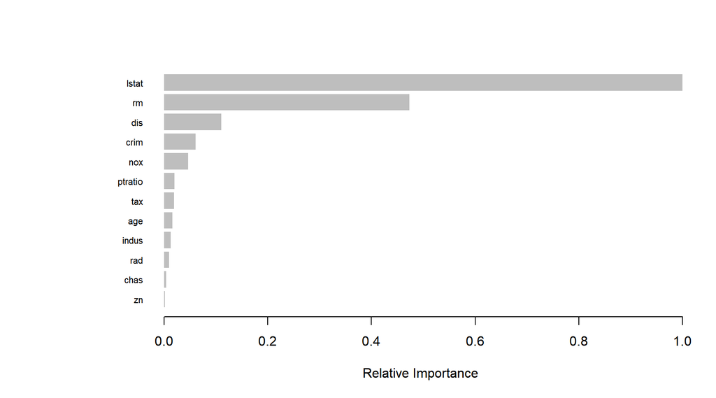

# References

James, G., D. Witten, T. Hastie, and R. Tibshirani. 2023. *An Introduction to Statistical Learning with Applications in r*. Second edition. Springer.

Lantz, Brett. 2023. *Machine Learning with r : Learn Techniques for Building and Improving Machine Learning Models, from Data Preparation to Model Tuning, Evaluation, and Working with Big Data*. Fourth edition. Expert Insight. Birmingham, UK: Packt Publishing Limited.